# Case Study 1

Hieu Nguyen

2022-10-27

Author: Hieu Nguyen

Date: 27 Oct 2022

## Intro

This is a case study I completed about a fictional company, Cyclistic. As a junior data analyst on their team, I will follow the data analysis process; ask, prepare, process, analyze, share, and act.

### About the company

In 2016, Cyclistic launched a successful bike-share offering. Since then, the program has grown to a fleet of 5,824 bicycles that are geotracked and locked into a network of 692 stations across Chicago. The bikes can be unlocked from one station and returned to any other station in the system anytime. Until now, Cyclistic’s marketing strategy relied on building general awareness and appealing to broad consumer segments. One approach that helped make these things possible was the flexibility of its pricing plans: single-ride passes, full-day passes, and annual memberships. Customers who purchase single-ride or full-day passes are referred to as casual riders. Customers who purchase annual memberships are Cyclistic members. Cyclistic’s finance analysts have concluded that annual members are much more profitable than casual riders. Although the pricing flexibility helps Cyclistic attract more customers, Moreno believes that maximizing the number of annual members will be key to future growth. Rather than creating a marketing campaign that targets all-new customers, Moreno believes there is a very good chance to convert casual riders into members. She notes that casual riders are already aware of the Cyclistic program and have chosen Cyclistic for their mobility needs. Moreno has set a clear goal: Design marketing strategies aimed at converting casual riders into annual members. In order to do that, however, the marketing analyst team needs to better understand how annual members and casual riders differ, why casual riders would buy a membership, and how digital media could affect their marketing tactics. Moreno and her team are interested in analyzing the Cyclistic historical bike trip data to identify trends.

## Ask

Business’s task: How do annual members and casual riders use Cyclistic bikes differently?

## Prepare

### Data Source

The data is stored in the public dataset “tripdata-cyclists” from the website https://divvy-tripdata.s3.amazonaws.com/index.html and the last 12 months of data was concidered. The data has been made available by Motivate International Inc. under this license: https://ride.divvybikes.com/data-license-agreement. The data is organized in 13 columns in 12 differnt CSV files, one for each month.

### Preparation of data for analysis

Data cleaning in spreadsheets will be time-consuming and slow compared to SQL or R. Because the combined size of all the 12 datasets is larger than 1Gb. I decided to use R. Because I can do wrangling and analysis/ visualizations in the same platform.

## Process

### Load libraries

```r
library(tidyverse)
```

```r
library(ggplot2)
library(lubridate)
library(dplyr)
library(readr)
library(data.table)
library(tidyr)
```

### Load CSV files

```r
tripdata_202110 <- read.csv("~/Chứng chỉ google/Case Study 1/202110-divvy-tripdata.csv")
tripdata_202111 <- read.csv("~/Chứng chỉ google/Case Study 1/202111-divvy-tripdata.csv")
tripdata_202112 <- read.csv("~/Chứng chỉ google/Case Study 1/202112-divvy-tripdata.csv")
tripdata_202201 <- read.csv("~/Chứng chỉ google/Case Study 1/202201-divvy-tripdata.csv")
tripdata_202202 <- read.csv("~/Chứng chỉ google/Case Study 1/202202-divvy-tripdata.csv")
tripdata_202203 <- read.csv("~/Chứng chỉ google/Case Study 1/202203-divvy-tripdata.csv")
tripdata_202204 <- read.csv("~/Chứng chỉ google/Case Study 1/202204-divvy-tripdata.csv")
tripdata_202205 <- read.csv("~/Chứng chỉ google/Case Study 1/202205-divvy-tripdata.csv")
tripdata_202206 <- read.csv("~/Chứng chỉ google/Case Study 1/202206-divvy-tripdata.csv")
tripdata_202207 <- read.csv("~/Chứng chỉ google/Case Study 1/202207-divvy-tripdata.csv")
tripdata_202208 <- read.csv("~/Chứng chỉ google/Case Study 1/202208-divvy-tripdata.csv")
tripdata_202209 <- read.csv("~/Chứng chỉ google/Case Study 1/202209-divvy-publictripdata.csv")
```

### Check column names of each dataset for consistency

```r
colnames(tripdata_202110)
```

```
##  [1] "ride_id"            "rideable_type"      "started_at"
##  [4] "ended_at"           "start_station_name" "start_station_id"
##  [7] "end_station_name"   "end_station_id"     "start_lat"
## [10] "start_lng"          "end_lat"            "end_lng"
## [13] "member_casual"
```

```r
colnames(tripdata_202111)
```

```
##  [1] "ride_id"            "rideable_type"      "started_at"
##  [4] "ended_at"           "start_station_name" "start_station_id"
##  [7] "end_station_name"   "end_station_id"     "start_lat"
## [10] "start_lng"          "end_lat"            "end_lng"
## [13] "member_casual"
```

```r
colnames(tripdata_202112)
```

```
##  [1] "ride_id"            "rideable_type"      "started_at"
##  [4] "ended_at"           "start_station_name" "start_station_id"
##  [7] "end_station_name"   "end_station_id"     "start_lat"
## [10] "start_lng"          "end_lat"            "end_lng"
## [13] "member_casual"
```

```r
colnames(tripdata_202201)
```

```
##  [1] "ride_id"            "rideable_type"      "started_at"
##  [4] "ended_at"           "start_station_name" "start_station_id"
##  [7] "end_station_name"   "end_station_id"     "start_lat"
## [10] "start_lng"          "end_lat"            "end_lng"
## [13] "member_casual"
```

```r
colnames(tripdata_202202)
```

```
##  [1] "ride_id"            "rideable_type"      "started_at"
##  [4] "ended_at"           "start_station_name" "start_station_id"
##  [7] "end_station_name"   "end_station_id"     "start_lat"
## [10] "start_lng"          "end_lat"            "end_lng"
## [13] "member_casual"
```

```r
colnames(tripdata_202203)
```

```
##  [1] "ride_id"            "rideable_type"      "started_at"
##  [4] "ended_at"           "start_station_name" "start_station_id"
##  [7] "end_station_name"   "end_station_id"     "start_lat"
## [10] "start_lng"          "end_lat"            "end_lng"
## [13] "member_casual"
```

```r
colnames(tripdata_202204)
```

```
##  [1] "ride_id"            "rideable_type"      "started_at"
##  [4] "ended_at"           "start_station_name" "start_station_id"
##  [7] "end_station_name"   "end_station_id"     "start_lat"
## [10] "start_lng"          "end_lat"            "end_lng"
## [13] "member_casual"
```

```r
colnames(tripdata_202205)
```

```
##  [1] "ride_id"            "rideable_type"      "started_at"
##  [4] "ended_at"           "start_station_name" "start_station_id"
##  [7] "end_station_name"   "end_station_id"     "start_lat"
## [10] "start_lng"          "end_lat"            "end_lng"
## [13] "member_casual"
```

```r
colnames(tripdata_202206)
```

```
##  [1] "ride_id"            "rideable_type"      "started_at"
##  [4] "ended_at"           "start_station_name" "start_station_id"
##  [7] "end_station_name"   "end_station_id"     "start_lat"
## [10] "start_lng"          "end_lat"            "end_lng"
## [13] "member_casual"
```

```r
colnames(tripdata_202207)
```

```
##  [1] "ride_id"            "rideable_type"      "started_at"
##  [4] "ended_at"           "start_station_name" "start_station_id"
##  [7] "end_station_name"   "end_station_id"     "start_lat"
## [10] "start_lng"          "end_lat"            "end_lng"
## [13] "member_casual"
```

```r
colnames(tripdata_202208)
```

```
##  [1] "ride_id"            "rideable_type"      "started_at"
##  [4] "ended_at"           "start_station_name" "start_station_id"
##  [7] "end_station_name"   "end_station_id"     "start_lat"
## [10] "start_lng"          "end_lat"            "end_lng"
## [13] "member_casual"
```

```r
colnames(tripdata_202209)
```

```
##  [1] "ride_id"            "rideable_type"      "started_at"
##  [4] "ended_at"           "start_station_name" "start_station_id"
##  [7] "end_station_name"   "end_station_id"     "start_lat"
## [10] "start_lng"          "end_lat"            "end_lng"
## [13] "member_casual"
```

### Check data structures and data types for all data frames

```r
str(tripdata_202110)
```

```
## 'data.frame':    631226 obs. of  13 variables:
##  $ ride_id           : chr  "620BC6107255BF4C" "4471C70731AB2E45" "26CA69D43D15EE14" "362947F0437E1514" ...
##  $ rideable_type     : chr  "electric_bike" "electric_bike" "electric_bike" "electric_bike" ...
##  $ started_at        : chr  "2021-10-22 12:46:42" "2021-10-21 09:12:37" "2021-10-16 16:28:39" "2021-10-16 16:17:48" ...
##  $ ended_at          : chr  "2021-10-22 12:49:50" "2021-10-21 09:14:14" "2021-10-16 16:36:26" "2021-10-16 16:19:03" ...
##  $ start_station_name: chr  "Kingsbury St & Kinzie St" "" "" "" ...
##  $ start_station_id  : chr  "KA1503000043" "" "" "" ...
##  $ end_station_name  : chr  "" "" "" "" ...
##  $ end_station_id    : chr  "" "" "" "" ...
##  $ start_lat         : num  41.9 41.9 41.9 41.9 41.9 ...
##  $ start_lng         : num  -87.6 -87.7 -87.7 -87.7 -87.7 ...
##  $ end_lat           : num  41.9 41.9 41.9 41.9 41.9 ...
##  $ end_lng           : num  -87.6 -87.7 -87.7 -87.7 -87.7 ...
##  $ member_casual     : chr  "member" "member" "member" "member" ...
```

```r
str(tripdata_202111)
```

```
## 'data.frame':    359978 obs. of  13 variables:
##  $ ride_id           : chr  "7C00A93E10556E47" "90854840DFD508BA" "0A7D10CDD144061C" "2F3BE33085BCFF02" ...
##  $ rideable_type     : chr  "electric_bike" "electric_bike" "electric_bike" "electric_bike" ...
##  $ started_at        : chr  "2021-11-27 13:27:38" "2021-11-27 13:38:25" "2021-11-26 22:03:34" "2021-11-27 09:56:49" ...
##  $ ended_at          : chr  "2021-11-27 13:46:38" "2021-11-27 13:56:10" "2021-11-26 22:05:56" "2021-11-27 10:01:50" ...
##  $ start_station_name: chr  "" "" "" "" ...
##  $ start_station_id  : chr  "" "" "" "" ...
##  $ end_station_name  : chr  "" "" "" "" ...
##  $ end_station_id    : chr  "" "" "" "" ...
##  $ start_lat         : num  41.9 42 42 41.9 41.9 ...
##  $ start_lng         : num  -87.7 -87.7 -87.7 -87.8 -87.6 ...
##  $ end_lat           : num  42 41.9 42 41.9 41.9 ...
##  $ end_lng           : num  -87.7 -87.7 -87.7 -87.8 -87.6 ...
##  $ member_casual     : chr  "casual" "casual" "casual" "casual" ...
```

```r
str(tripdata_202112)
```

```
## 'data.frame':    247540 obs. of  13 variables:
##  $ ride_id           : chr  "46F8167220E4431F" "73A77762838B32FD" "4CF42452054F59C5" "3278BA87BF698339" ...
##  $ rideable_type     : chr  "electric_bike" "electric_bike" "electric_bike" "classic_bike" ...
##  $ started_at        : chr  "2021-12-07 15:06:07" "2021-12-11 03:43:29" "2021-12-15 23:10:28" "2021-12-26 16:16:10" ...
##  $ ended_at          : chr  "2021-12-07 15:13:42" "2021-12-11 04:10:23" "2021-12-15 23:23:14" "2021-12-26 16:30:53" ...
##  $ start_station_name: chr  "Laflin St & Cullerton St" "LaSalle Dr & Huron St" "Halsted St & North Branch St" "Halsted St & North Branch St" ...
##  $ start_station_id  : chr  "13307" "KP1705001026" "KA1504000117" "KA1504000117" ...
##  $ end_station_name  : chr  "Morgan St & Polk St" "Clarendon Ave & Leland Ave" "Broadway & Barry Ave" "LaSalle Dr & Huron St" ...
##  $ end_station_id    : chr  "TA1307000130" "TA1307000119" "13137" "KP1705001026" ...
##  $ start_lat         : num  41.9 41.9 41.9 41.9 41.9 ...
##  $ start_lng         : num  -87.7 -87.6 -87.6 -87.6 -87.7 ...
##  $ end_lat           : num  41.9 42 41.9 41.9 41.9 ...
##  $ end_lng           : num  -87.7 -87.7 -87.6 -87.6 -87.6 ...
##  $ member_casual     : chr  "member" "casual" "member" "member" ...
```

```r
str(tripdata_202201)
```

```
## 'data.frame':    103770 obs. of  13 variables:
##  $ ride_id           : chr  "C2F7DD78E82EC875" "A6CF8980A652D272" "BD0F91DFF741C66D" "CBB80ED419105406" ...
##  $ rideable_type     : chr  "electric_bike" "electric_bike" "classic_bike" "classic_bike" ...
##  $ started_at        : chr  "2022-01-13 11:59:47" "2022-01-10 08:41:56" "2022-01-25 04:53:40" "2022-01-04 00:18:04" ...
##  $ ended_at          : chr  "2022-01-13 12:02:44" "2022-01-10 08:46:17" "2022-01-25 04:58:01" "2022-01-04 00:33:00" ...
##  $ start_station_name: chr  "Glenwood Ave & Touhy Ave" "Glenwood Ave & Touhy Ave" "Sheffield Ave & Fullerton Ave" "Clark St & Bryn Mawr Ave" ...
##  $ start_station_id  : chr  "525" "525" "TA1306000016" "KA1504000151" ...
##  $ end_station_name  : chr  "Clark St & Touhy Ave" "Clark St & Touhy Ave" "Greenview Ave & Fullerton Ave" "Paulina St & Montrose Ave" ...
##  $ end_station_id    : chr  "RP-007" "RP-007" "TA1307000001" "TA1309000021" ...
##  $ start_lat         : num  42 42 41.9 42 41.9 ...
##  $ start_lng         : num  -87.7 -87.7 -87.7 -87.7 -87.6 ...
##  $ end_lat           : num  42 42 41.9 42 41.9 ...
##  $ end_lng           : num  -87.7 -87.7 -87.7 -87.7 -87.6 ...
##  $ member_casual     : chr  "casual" "casual" "member" "casual" ...
```

```r
str(tripdata_202202)
```

```
## 'data.frame':    115609 obs. of  13 variables:
##  $ ride_id           : chr  "E1E065E7ED285C02" "1602DCDC5B30FFE3" "BE7DD2AF4B55C4AF" "A1789BDF844412BE" ...
##  $ rideable_type     : chr  "classic_bike" "classic_bike" "classic_bike" "classic_bike" ...
##  $ started_at        : chr  "2022-02-19 18:08:41" "2022-02-20 17:41:30" "2022-02-25 18:55:56" "2022-02-14 11:57:03" ...
##  $ ended_at          : chr  "2022-02-19 18:23:56" "2022-02-20 17:45:56" "2022-02-25 19:09:34" "2022-02-14 12:04:00" ...
##  $ start_station_name: chr  "State St & Randolph St" "Halsted St & Wrightwood Ave" "State St & Randolph St" "Southport Ave & Waveland Ave" ...
##  $ start_station_id  : chr  "TA1305000029" "TA1309000061" "TA1305000029" "13235" ...
##  $ end_station_name  : chr  "Clark St & Lincoln Ave" "Southport Ave & Wrightwood Ave" "Canal St & Adams St" "Broadway & Sheridan Rd" ...
##  $ end_station_id    : chr  "13179" "TA1307000113" "13011" "13323" ...
##  $ start_lat         : num  41.9 41.9 41.9 41.9 41.9 ...
##  $ start_lng         : num  -87.6 -87.6 -87.6 -87.7 -87.6 ...
##  $ end_lat           : num  41.9 41.9 41.9 42 41.9 ...
##  $ end_lng           : num  -87.6 -87.7 -87.6 -87.6 -87.6 ...
##  $ member_casual     : chr  "member" "member" "member" "member" ...
```

```r
str(tripdata_202203)
```

```
## 'data.frame':    284042 obs. of  13 variables:
##  $ ride_id           : chr  "47EC0A7F82E65D52" "8494861979B0F477" "EFE527AF80B66109" "9F446FD9DEE3F389" ...
##  $ rideable_type     : chr  "classic_bike" "electric_bike" "classic_bike" "classic_bike" ...
##  $ started_at        : chr  "2022-03-21 13:45:01" "2022-03-16 09:37:16" "2022-03-23 19:52:02" "2022-03-01 19:12:26" ...
##  $ ended_at          : chr  "2022-03-21 13:51:18" "2022-03-16 09:43:34" "2022-03-23 19:54:48" "2022-03-01 19:22:14" ...
##  $ start_station_name: chr  "Wabash Ave & Wacker Pl" "Michigan Ave & Oak St" "Broadway & Berwyn Ave" "Wabash Ave & Wacker Pl" ...
##  $ start_station_id  : chr  "TA1307000131" "13042" "13109" "TA1307000131" ...
##  $ end_station_name  : chr  "Kingsbury St & Kinzie St" "Orleans St & Chestnut St (NEXT Apts)" "Broadway & Ridge Ave" "Franklin St & Jackson Blvd" ...
##  $ end_station_id    : chr  "KA1503000043" "620" "15578" "TA1305000025" ...
##  $ start_lat         : num  41.9 41.9 42 41.9 41.9 ...
##  $ start_lng         : num  -87.6 -87.6 -87.7 -87.6 -87.6 ...
##  $ end_lat           : num  41.9 41.9 42 41.9 41.9 ...
##  $ end_lng           : num  -87.6 -87.6 -87.7 -87.6 -87.7 ...
##  $ member_casual     : chr  "member" "member" "member" "member" ...
```

```r
str(tripdata_202204)
```

```
## 'data.frame':    371249 obs. of  13 variables:
##  $ ride_id           : chr  "3564070EEFD12711" "0B820C7FCF22F489" "89EEEE32293F07FF" "84D4751AEB31888D" ...
##  $ rideable_type     : chr  "electric_bike" "classic_bike" "classic_bike" "classic_bike" ...
##  $ started_at        : chr  "2022-04-06 17:42:48" "2022-04-24 19:23:07" "2022-04-20 19:29:08" "2022-04-22 21:14:06" ...
##  $ ended_at          : chr  "2022-04-06 17:54:36" "2022-04-24 19:43:17" "2022-04-20 19:35:16" "2022-04-22 21:23:29" ...
##  $ start_station_name: chr  "Paulina St & Howard St" "Wentworth Ave & Cermak Rd" "Halsted St & Polk St" "Wentworth Ave & Cermak Rd" ...
##  $ start_station_id  : chr  "515" "13075" "TA1307000121" "13075" ...
##  $ end_station_name  : chr  "University Library (NU)" "Green St & Madison St" "Green St & Madison St" "Delano Ct & Roosevelt Rd" ...
##  $ end_station_id    : chr  "605" "TA1307000120" "TA1307000120" "KA1706005007" ...
##  $ start_lat         : num  42 41.9 41.9 41.9 41.9 ...
##  $ start_lng         : num  -87.7 -87.6 -87.6 -87.6 -87.6 ...
##  $ end_lat           : num  42.1 41.9 41.9 41.9 41.9 ...
##  $ end_lng           : num  -87.7 -87.6 -87.6 -87.6 -87.6 ...
##  $ member_casual     : chr  "member" "member" "member" "casual" ...
```

```r
str(tripdata_202205)
```

```
## 'data.frame':    634858 obs. of  13 variables:
##  $ ride_id           : chr  "EC2DE40644C6B0F4" "1C31AD03897EE385" "1542FBEC830415CF" "6FF59852924528F8" ...
##  $ rideable_type     : chr  "classic_bike" "classic_bike" "classic_bike" "classic_bike" ...
##  $ started_at        : chr  "2022-05-23 23:06:58" "2022-05-11 08:53:28" "2022-05-26 18:36:28" "2022-05-10 07:30:07" ...
##  $ ended_at          : chr  "2022-05-23 23:40:19" "2022-05-11 09:31:22" "2022-05-26 18:58:18" "2022-05-10 07:38:49" ...
##  $ start_station_name: chr  "Wabash Ave & Grand Ave" "DuSable Lake Shore Dr & Monroe St" "Clinton St & Madison St" "Clinton St & Madison St" ...
##  $ start_station_id  : chr  "TA1307000117" "13300" "TA1305000032" "TA1305000032" ...
##  $ end_station_name  : chr  "Halsted St & Roscoe St" "Field Blvd & South Water St" "Wood St & Milwaukee Ave" "Clark St & Randolph St" ...
##  $ end_station_id    : chr  "TA1309000025" "15534" "13221" "TA1305000030" ...
##  $ start_lat         : num  41.9 41.9 41.9 41.9 41.9 ...
##  $ start_lng         : num  -87.6 -87.6 -87.6 -87.6 -87.6 ...
##  $ end_lat           : num  41.9 41.9 41.9 41.9 41.9 ...
##  $ end_lng           : num  -87.6 -87.6 -87.7 -87.6 -87.7 ...
##  $ member_casual     : chr  "member" "member" "member" "member" ...
```

```r
str(tripdata_202206)
```

```
## 'data.frame':    769204 obs. of  13 variables:
##  $ ride_id           : chr  "600CFD130D0FD2A4" "F5E6B5C1682C6464" "B6EB6D27BAD771D2" "C9C320375DE1D5C6" ...
##  $ rideable_type     : chr  "electric_bike" "electric_bike" "electric_bike" "electric_bike" ...
##  $ started_at        : chr  "2022-06-30 17:27:53" "2022-06-30 18:39:52" "2022-06-30 11:49:25" "2022-06-30 11:15:25" ...
##  $ ended_at          : chr  "2022-06-30 17:35:15" "2022-06-30 18:47:28" "2022-06-30 12:02:54" "2022-06-30 11:19:43" ...
##  $ start_station_name: chr  "" "" "" "" ...
##  $ start_station_id  : chr  "" "" "" "" ...
##  $ end_station_name  : chr  "" "" "" "" ...
##  $ end_station_id    : chr  "" "" "" "" ...
##  $ start_lat         : num  41.9 41.9 41.9 41.8 41.9 ...
##  $ start_lng         : num  -87.6 -87.6 -87.7 -87.7 -87.6 ...
##  $ end_lat           : num  41.9 41.9 41.9 41.8 41.9 ...
##  $ end_lng           : num  -87.6 -87.6 -87.6 -87.7 -87.6 ...
##  $ member_casual     : chr  "casual" "casual" "casual" "casual" ...
```

```r
str(tripdata_202207)
```

```
## 'data.frame':    823488 obs. of  13 variables:
##  $ ride_id           : chr  "954144C2F67B1932" "292E027607D218B6" "57765852588AD6E0" "B5B6BE44314590E6" ...
##  $ rideable_type     : chr  "classic_bike" "classic_bike" "classic_bike" "classic_bike" ...
##  $ started_at        : chr  "2022-07-05 08:12:47" "2022-07-26 12:53:38" "2022-07-03 13:58:49" "2022-07-31 17:44:21" ...
##  $ ended_at          : chr  "2022-07-05 08:24:32" "2022-07-26 12:55:31" "2022-07-03 14:06:32" "2022-07-31 18:42:50" ...
##  $ start_station_name: chr  "Ashland Ave & Blackhawk St" "Buckingham Fountain (Temp)" "Buckingham Fountain (Temp)" "Buckingham Fountain (Temp)" ...
##  $ start_station_id  : chr  "13224" "15541" "15541" "15541" ...
##  $ end_station_name  : chr  "Kingsbury St & Kinzie St" "Michigan Ave & 8th St" "Michigan Ave & 8th St" "Woodlawn Ave & 55th St" ...
##  $ end_station_id    : chr  "KA1503000043" "623" "623" "TA1307000164" ...
##  $ start_lat         : num  41.9 41.9 41.9 41.9 41.9 ...
##  $ start_lng         : num  -87.7 -87.6 -87.6 -87.6 -87.6 ...
##  $ end_lat           : num  41.9 41.9 41.9 41.8 41.9 ...
##  $ end_lng           : num  -87.6 -87.6 -87.6 -87.6 -87.7 ...
##  $ member_casual     : chr  "member" "casual" "casual" "casual" ...
```

```r
str(tripdata_202208)
```

```
## 'data.frame':    785932 obs. of  13 variables:
##  $ ride_id           : chr  "550CF7EFEAE0C618" "DAD198F405F9C5F5" "E6F2BC47B65CB7FD" "F597830181C2E13C" ...
##  $ rideable_type     : chr  "electric_bike" "electric_bike" "electric_bike" "electric_bike" ...
##  $ started_at        : chr  "2022-08-07 21:34:15" "2022-08-08 14:39:21" "2022-08-08 15:29:50" "2022-08-08 02:43:50" ...
##  $ ended_at          : chr  "2022-08-07 21:41:46" "2022-08-08 14:53:23" "2022-08-08 15:40:34" "2022-08-08 02:58:53" ...
##  $ start_station_name: chr  "" "" "" "" ...
##  $ start_station_id  : chr  "" "" "" "" ...
##  $ end_station_name  : chr  "" "" "" "" ...
##  $ end_station_id    : chr  "" "" "" "" ...
##  $ start_lat         : num  41.9 41.9 42 41.9 41.9 ...
##  $ start_lng         : num  -87.7 -87.6 -87.7 -87.7 -87.7 ...
##  $ end_lat           : num  41.9 41.9 42 42 41.8 ...
##  $ end_lng           : num  -87.7 -87.6 -87.7 -87.7 -87.7 ...
##  $ member_casual     : chr  "casual" "casual" "casual" "casual" ...
```

```r
str(tripdata_202209)
```

```
## 'data.frame':    701339 obs. of  13 variables:
##  $ ride_id           : chr  "5156990AC19CA285" "E12D4A16BF51C274" "A02B53CD7DB72DD7" "C82E05FEE872DF11" ...
##  $ rideable_type     : chr  "electric_bike" "electric_bike" "electric_bike" "electric_bike" ...
##  $ started_at        : chr  "2022-09-01 08:36:22" "2022-09-01 17:11:29" "2022-09-01 17:15:50" "2022-09-01 09:00:28" ...
##  $ ended_at          : chr  "2022-09-01 08:39:05" "2022-09-01 17:14:45" "2022-09-01 17:16:12" "2022-09-01 09:10:32" ...
##  $ start_station_name: chr  "" "" "" "" ...
##  $ start_station_id  : chr  "" "" "" "" ...
##  $ end_station_name  : chr  "California Ave & Milwaukee Ave" "" "" "" ...
##  $ end_station_id    : chr  "13084" "" "" "" ...
##  $ start_lat         : num  41.9 41.9 41.9 41.9 41.9 ...
##  $ start_lng         : num  -87.7 -87.6 -87.6 -87.7 -87.7 ...
##  $ end_lat           : num  41.9 41.9 41.9 41.9 41.9 ...
##  $ end_lng           : num  -87.7 -87.6 -87.6 -87.7 -87.7 ...
##  $ member_casual     : chr  "casual" "casual" "casual" "casual" ...
```

All datasets are consistent. Combine all the datasets into one single dataframe. View combined file’s information.

```r
combined <- bind_rows(tripdata_202110, tripdata_202111, tripdata_202112, tripdata_202201, tripdata_202202,tripdata_202203, tripdata_202204, tripdata_202205, tripdata_202206, tripdata_202207, tripdata_202208, tripdata_202209)
str(combined)
```

```
## 'data.frame':    5828235 obs. of  13 variables:
##  $ ride_id           : chr  "620BC6107255BF4C" "4471C70731AB2E45" "26CA69D43D15EE14" "362947F0437E1514" ...
##  $ rideable_type     : chr  "electric_bike" "electric_bike" "electric_bike" "electric_bike" ...
##  $ started_at        : chr  "2021-10-22 12:46:42" "2021-10-21 09:12:37" "2021-10-16 16:28:39" "2021-10-16 16:17:48" ...
##  $ ended_at          : chr  "2021-10-22 12:49:50" "2021-10-21 09:14:14" "2021-10-16 16:36:26" "2021-10-16 16:19:03" ...
##  $ start_station_name: chr  "Kingsbury St & Kinzie St" "" "" "" ...
##  $ start_station_id  : chr  "KA1503000043" "" "" "" ...
##  $ end_station_name  : chr  "" "" "" "" ...
##  $ end_station_id    : chr  "" "" "" "" ...
##  $ start_lat         : num  41.9 41.9 41.9 41.9 41.9 ...
##  $ start_lng         : num  -87.6 -87.7 -87.7 -87.7 -87.7 ...
##  $ end_lat           : num  41.9 41.9 41.9 41.9 41.9 ...
##  $ end_lng           : num  -87.6 -87.7 -87.7 -87.7 -87.7 ...
##  $ member_casual     : chr  "member" "member" "member" "member" ...
```

Convert datatype of started_at & ended_at from char to datetime.

```r
combined[['started_at']] <- ymd_hms(combined[['started_at']])
combined[['ended_at']] <- ymd_hms(combined[['ended_at']])
```

View combined file’s information.

```r
str(combined)
```

```
## 'data.frame':    5828235 obs. of  13 variables:
##  $ ride_id           : chr  "620BC6107255BF4C" "4471C70731AB2E45" "26CA69D43D15EE14" "362947F0437E1514" ...
##  $ rideable_type     : chr  "electric_bike" "electric_bike" "electric_bike" "electric_bike" ...
##  $ started_at        : POSIXct, format: "2021-10-22 12:46:42" "2021-10-21 09:12:37" ...
##  $ ended_at          : POSIXct, format: "2021-10-22 12:49:50" "2021-10-21 09:14:14" ...
##  $ start_station_name: chr  "Kingsbury St & Kinzie St" "" "" "" ...
##  $ start_station_id  : chr  "KA1503000043" "" "" "" ...
##  $ end_station_name  : chr  "" "" "" "" ...
##  $ end_station_id    : chr  "" "" "" "" ...
##  $ start_lat         : num  41.9 41.9 41.9 41.9 41.9 ...
##  $ start_lng         : num  -87.6 -87.7 -87.7 -87.7 -87.7 ...
##  $ end_lat           : num  41.9 41.9 41.9 41.9 41.9 ...
##  $ end_lng           : num  -87.6 -87.7 -87.7 -87.7 -87.7 ...
##  $ member_casual     : chr  "member" "member" "member" "member" ...
```

Remove columns

```r
combined <- combined %>%
  select(-c(start_lat:end_lng))
```

Add new columns that can be used for aggregate functions

```r
combined$day_of_the_week <- format(as.Date(combined$started_at), '%a')
combined$month <- format(as.Date(combined$started_at), '%b_%y')
combined <- mutate(combined, time_difference_hours = difftime(ended_at, started_at, units = "hours"))
```

Checking for time_difference_hours less than 0

```r
nrow(subset(combined,time_difference_hours < 0))
```

```
## [1] 108
```

Checking for testrides that were made by company for quality checks

```r
nrow(subset(combined, start_station_name %like% "Test"))
```

```
## [1] 1
```

As there are 108 rows with time_difference_hours less than 0 hour and 1 trip that were test rides, will remove these observations from my dataframe.

```r
combined_v2 <- combined[!(combined$time_difference_hours < 0),]
```

```r
combined_v2<- combined_v2[!((combined_v2$start_station_name %like% "Test")),]
```

```r
glimpse(combined_v2)
```

```
## Rows: 5,828,126
## Columns: 12
## $ ride_id               <chr> "620BC6107255BF4C", "4471C70731AB2E45", "26CA69D…
## $ rideable_type         <chr> "electric_bike", "electric_bike", "electric_bike…
## $ started_at            <dttm> 2021-10-22 12:46:42, 2021-10-21 09:12:37, 2021-…
## $ ended_at              <dttm> 2021-10-22 12:49:50, 2021-10-21 09:14:14, 2021-…
## $ start_station_name    <chr> "Kingsbury St & Kinzie St", "", "", "", "", "", …
## $ start_station_id      <chr> "KA1503000043", "", "", "", "", "", "", "", "", …
## $ end_station_name      <chr> "", "", "", "", "", "", "", "", "", "", "", "", …
## $ end_station_id        <chr> "", "", "", "", "", "", "", "", "", "", "", "", …
## $ member_casual         <chr> "member", "member", "member", "member", "member"…
## $ day_of_the_week       <chr> "Fri", "Thu", "Sat", "Sat", "Wed", "Thu", "Thu",…
## $ month                 <chr> "Oct_21", "Oct_21", "Oct_21", "Oct_21", "Oct_21"…
## $ time_difference_hours <drtn> 0.05222222 hours, 0.02694444 hours, 0.12972222 …
```

Check distinct value in table

```r
unique(combined_v2$rideable_type)
```

```
## [1] "electric_bike" "docked_bike"   "classic_bike"
```

```r
unique(combined_v2$member_casual)
```

```
## [1] "member" "casual"
```

```r
unique(combined_v2$month)
```

```
##  [1] "Oct_21" "Nov_21" "Dec_21" "Jan_22" "Feb_22" "Mar_22" "Apr_22" "May_22"
##  [9] "Jun_22" "Jul_22" "Aug_22" "Sep_22"
```

Checking count of distinct values

```r
table(combined_v2$member_casual)
```

```
##
##  casual  member
## 2401225 3426901
```

## Analyze

```r
summary.Date(combined_v2$time_difference_hours)
```

```
##      Min.   1st Qu.    Median      Mean   3rd Qu.      Max.
##   0.00000   0.09889   0.17472   0.32674   0.31417 678.41694
```

```r
combined_v2 %>%
    group_by(member_casual) %>%
    summarise(min_trip_duration = min(time_difference_hours),max_trip_duration = max(time_difference_hours),
              median_trip_duration = median(time_difference_hours), mean_trip_duration = mean(time_difference_hours))
```

```
## # A tibble: 2 × 5
##   member_casual min_trip_duration max_trip_duration median_trip_duration mean_…¹
##   <chr>         <drtn>            <drtn>            <drtn>               <drtn>
## 1 casual        0 hours           678.41694 hours   0.2241667 hours      0.4893…
## 2 member        0 hours            25.99833 hours   0.1480556 hours      0.2128…
## # … with abbreviated variable name ¹mean_trip_duration
```

Fix the order for the day_of_the_week and month variable so that they show up in the same sequence in output tables and visualizations

```r
combined_v2$day_of_the_week <- ordered(combined_v2$day_of_the_week, levels=c("Mon", "Tue", "Wed", "Thu", "Fri", "Sat", "Sun"))
```

```r
combined_v2$month <- ordered(combined_v2$month, levels=c("Oct_21", "Nov_21", "Dec_21", "Jan_22", "Feb_22", "Mar_22", "Apr_22", "May_22", "Jun_22", "Jul_22", "Aug_22", "Sep_22"))
```

### Total trips by customer type Vs. Day of the week

```r
combined_v2 %>%
  group_by(member_casual, day_of_the_week) %>%
  summarise(number_of_rides = n(),average_duration_hours = mean(time_difference_hours)) %>%
  arrange(member_casual, desc(number_of_rides))
```

```
## # A tibble: 14 × 4
## # Groups:   member_casual [2]
##    member_casual day_of_the_week number_of_rides average_duration_hours
##    <chr>         <ord>                     <int> <drtn>
##  1 casual        Sat                      499801 0.5451477 hours
##  2 casual        Sun                      405009 0.5727427 hours
##  3 casual        Fri                      352507 0.4668514 hours
##  4 casual        Thu                      306691 0.4279945 hours
##  5 casual        Wed                      281660 0.4172353 hours
##  6 casual        Mon                      279785 0.4954723 hours
##  7 casual        Tue                      275772 0.4301521 hours
##  8 member        Tue                      541519 0.2027173 hours
##  9 member        Wed                      538488 0.2020467 hours
## 10 member        Thu                      530547 0.2049010 hours
## 11 member        Fri                      491465 0.2088071 hours
## 12 member        Mon                      473059 0.2054602 hours
## 13 member        Sat                      458222 0.2377280 hours
## 14 member        Sun                      393601 0.2369082 hours
```

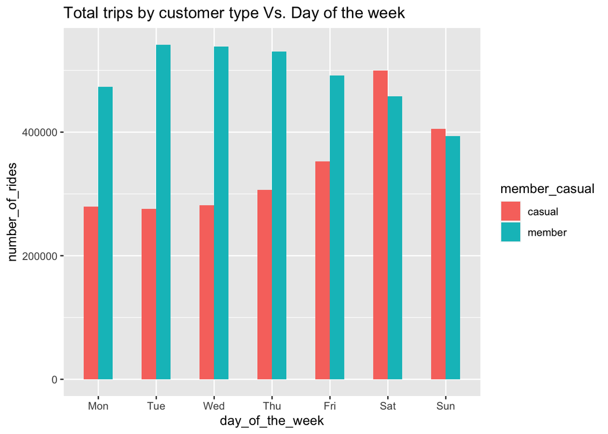

```r
combined_v2 %>%
  group_by(member_casual, day_of_the_week) %>%
  summarise(number_of_rides = n()) %>%
  arrange(member_casual, day_of_the_week)  %>%
  ggplot(aes(x = day_of_the_week, y = number_of_rides, fill = member_casual)) +
  labs(title ="Total trips by customer type Vs. Day of the week") +
  geom_col(width=0.5, position = position_dodge(width=0.5)) +
  scale_y_continuous(labels = function(x) format(x, scientific = FALSE))
```

From the table and graph above, casual customers are most busy on Saturdays followed by Sundays, while members tend to be different, they use the bikes much at the beginning of the week, most on Tuesdays and gradually decrease weekends. Perhaps it is because members use bikeshare services as a means of transportation to get to work, whereas casual do not. During the week, M uses more bicycles than C, the difference is great and progressively diminishes at the end of the week. At the end of the week, C uses the bicycle more, the difference is slight.

### Total trips by customer type Vs. Month

```r
combined_v2 %>%
  group_by(member_casual, month) %>%
  summarise(number_of_rides = n(),average_duration = mean(time_difference_hours)) %>%
  arrange(member_casual,desc(number_of_rides))
```

```
## # A tibble: 24 × 4
## # Groups:   member_casual [2]
##    member_casual month  number_of_rides average_duration
##    <chr>         <ord>            <int> <drtn>
##  1 casual        Jul_22          406046 0.4879808 hours
##  2 casual        Jun_22          369044 0.5349935 hours
##  3 casual        Aug_22          358917 0.4885108 hours
##  4 casual        Sep_22          296694 0.4664243 hours
##  5 casual        May_22          280414 0.5144954 hours
##  6 casual        Oct_21          257242 0.4778995 hours
##  7 casual        Apr_22          126417 0.4922071 hours
##  8 casual        Nov_21          106898 0.3855408 hours
##  9 casual        Mar_22           89880 0.5437197 hours
## 10 casual        Dec_21           69738 0.3915715 hours
## # … with 14 more rows
```

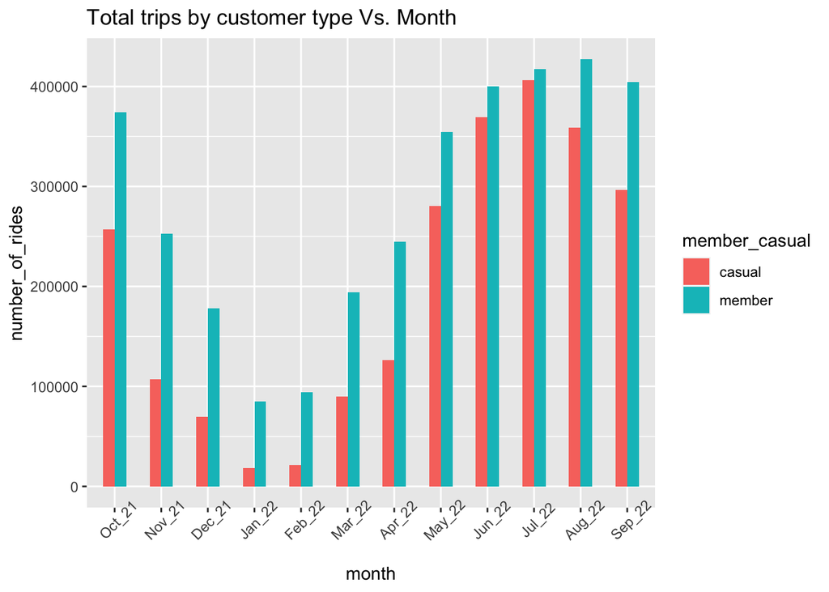

```r
combined_v2 %>%
  group_by(member_casual, month) %>%
  summarise(number_of_rides = n()) %>%
  arrange(member_casual, month)  %>%
  ggplot(aes(x = month, y = number_of_rides, fill = member_casual)) +
  labs(title ="Total trips by customer type Vs. Month") +
  theme(axis.text.x = element_text(angle = 45)) +
  geom_col(width=0.5, position = position_dodge(width=0.5)) +
  scale_y_continuous(labels = function(x) format(x, scientific = FALSE))
```

### Visualizaton of average trip duration by customer type on each day of the week

```
## Defaulting to continuous.
```

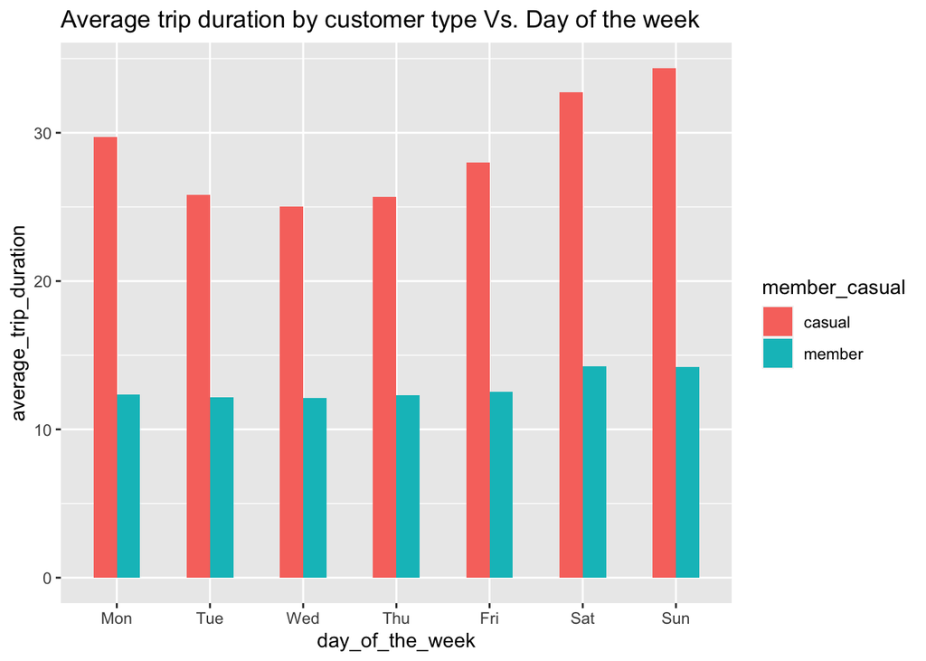

```r
combined_v2 %>%
  group_by(member_casual, day_of_the_week) %>%
  summarise(average_trip_duration = mean(time_difference_hours*60)) %>%
  ggplot(aes(x = day_of_the_week, y = average_trip_duration, fill = member_casual)) +
  geom_col(width=0.5, position = position_dodge(width=0.5)) +
  labs(title ="Average trip duration by customer type Vs. Day of the week")
```

The average trip duration of a casual rider is more than twice that of a member. Note that this necessarily does not mean that casual riders travel farther distance. It is also interesting to note that weekends not only contribute to more number of trips but also longer trips on average when compared to weekdays.

### Visualizaton of average trip duration by customer type Vs. month

```
## Defaulting to continuous.
```

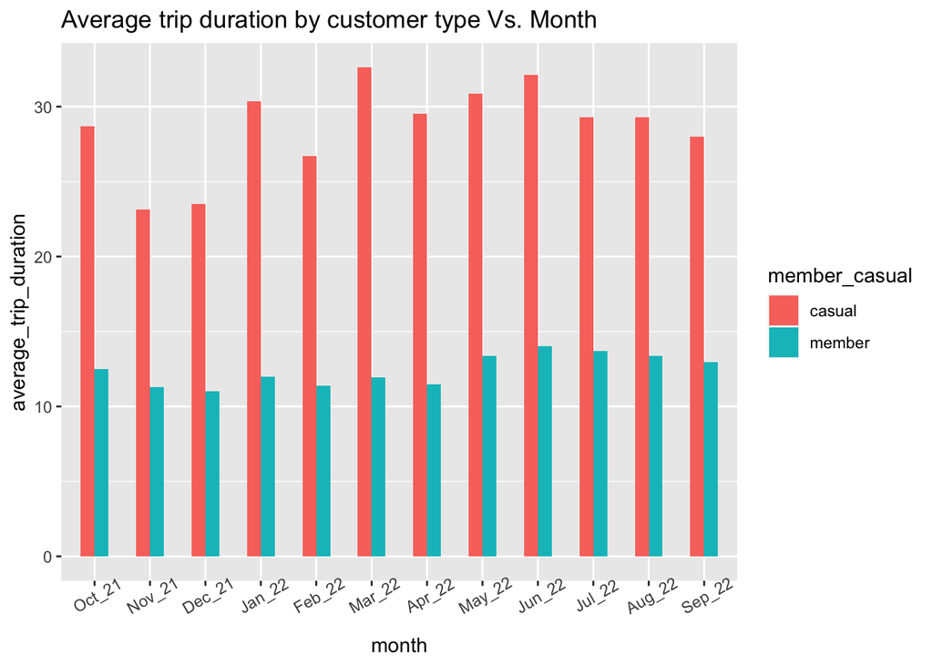

```r
combined_v2 %>%
  group_by(member_casual, month) %>%
  summarise(average_trip_duration = mean(time_difference_hours*60)) %>%
  ggplot(aes(x = month, y = average_trip_duration, fill = member_casual)) +
  geom_col(width=0.5, position = position_dodge(width=0.5)) +
  labs(title ="Average trip duration by customer type Vs. Month") +
  theme(axis.text.x = element_text(angle = 30))
```

The average trip duration of a casual rider is more than twice that of a member. Average trip duration of member riders is anywhere between 11-14 minutes throughout the year. While casual rider fluctuate more. The highest month is about 32 minutes for 1 trip, the lowest is 23 minutes.

### Visualizaton of bike demand over 24 hr period (a day)

Add time column

```r
combined_v2$time <- format(combined_v2$started_at, format = "%H:%M:%S")
```

```r
combined_v2$time <- as.POSIXct(combined_v2$time, format = "%H:%M:%S")
```

```r
str(combined_v2)
```

```
## 'data.frame':    5828126 obs. of  13 variables:
##  $ ride_id              : chr  "620BC6107255BF4C" "4471C70731AB2E45" "26CA69D43D15EE14" "362947F0437E1514" ...
##  $ rideable_type        : chr  "electric_bike" "electric_bike" "electric_bike" "electric_bike" ...
##  $ started_at           : POSIXct, format: "2021-10-22 12:46:42" "2021-10-21 09:12:37" ...
##  $ ended_at             : POSIXct, format: "2021-10-22 12:49:50" "2021-10-21 09:14:14" ...
##  $ start_station_name   : chr  "Kingsbury St & Kinzie St" "" "" "" ...
##  $ start_station_id     : chr  "KA1503000043" "" "" "" ...
##  $ end_station_name     : chr  "" "" "" "" ...
##  $ end_station_id       : chr  "" "" "" "" ...
##  $ member_casual        : chr  "member" "member" "member" "member" ...
##  $ day_of_the_week      : Ord.factor w/ 7 levels "Mon"<"Tue"<"Wed"<..: 5 4 6 6 3 4 4 3 4 3 ...
##  $ month                : Ord.factor w/ 12 levels "Oct_21"<"Nov_21"<..: 1 1 1 1 1 1 1 1 1 1 ...
##  $ time_difference_hours: 'difftime' num  0.0522222222222222 0.0269444444444444 0.129722222222222 0.0208333333333333 ...
##   ..- attr(*, "units")= chr "hours"
##  $ time                 : POSIXct, format: "2022-11-18 12:46:42" "2022-11-18 09:12:37" ...
```

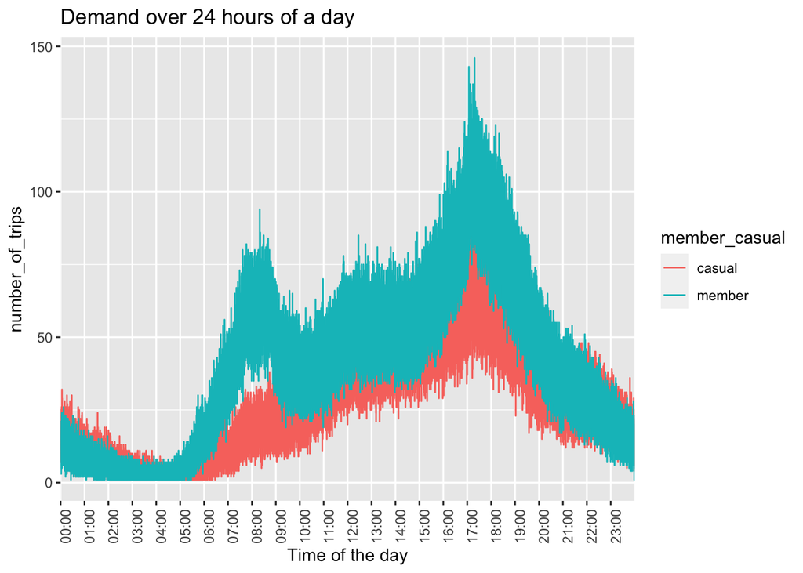

```r
combined_v2 %>%
  group_by(member_casual, time) %>%
  summarise(number_of_trips = n()) %>%
  ggplot(aes(x = time, y = number_of_trips, color = member_casual, group = member_casual)) +
  geom_line() +
  scale_x_datetime(date_breaks = "1 hour", minor_breaks = NULL,
                   date_labels = "%H:%M", expand = c(0,0)) +
  theme(axis.text.x = element_text(angle = 90)) +
  labs(title ="Demand over 24 hours of a day", x = "Time of the day")
```

Most of Member’s usage is more than Casual, even more than double, only less in the period from 10pm to 4am the next day. The two use a lot of bikes from 7am to 9am and from 4am to 6pm.

### Visualizaton of ride type Vs. number of trips by customer type

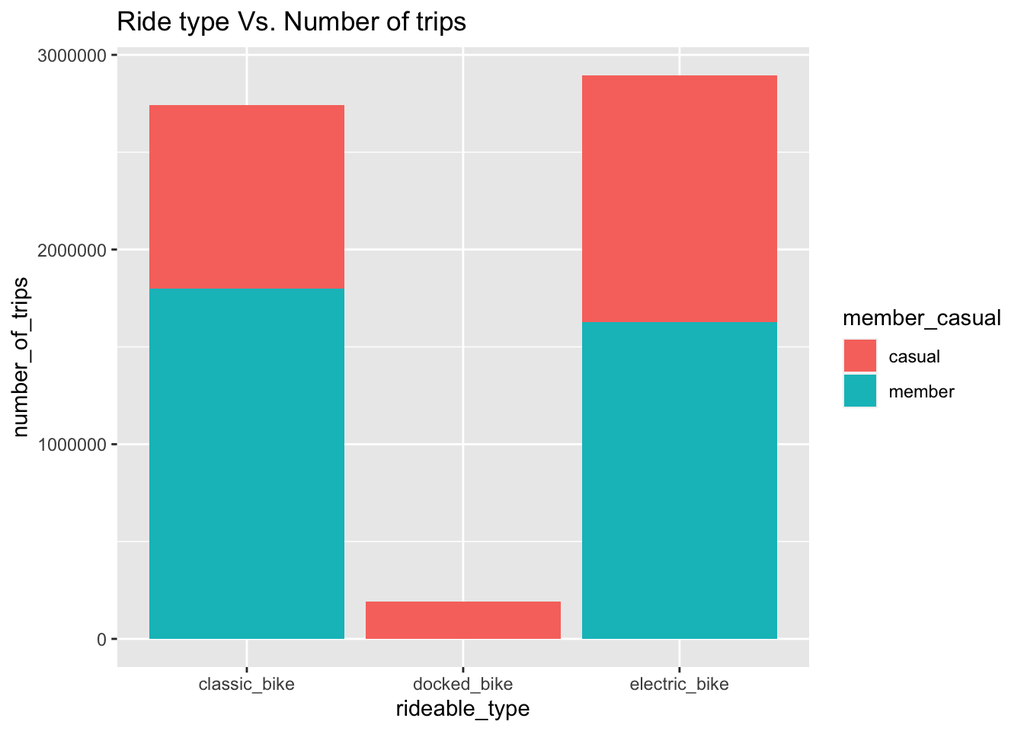

```r
combined_v2 %>%
  group_by(rideable_type, member_casual) %>%
  summarise(number_of_trips = n()) %>%
  ggplot(aes(x= rideable_type, y=number_of_trips, fill= member_casual))+
              geom_bar(stat='identity') +
  scale_y_continuous(labels = function(x) format(x, scientific = FALSE)) +
  labs(title ="Ride type Vs. Number of trips")
```

The number of people using docked bikes is very small, and only casual riders use this type of bike.Most members use a classic bike, more than an electric bike, most casual riders use an electric bike.

## Act

### Key takeaways

– In terms of the number of trips, Member rider is more on weekdays, and Casual rider is more on weekends. During the daytime, Member makes more trips than Casual rider, except for the hours from 10 pm to 4 am.

– In terms of average time duration, Casual rider is twice as long as Member rider. In the monthly surveys, the average duration of the member rider is less volatile, while that of the casual rider is much more variable in months compared.

– In terms of the type of bike used, Member rider uses mostly classic bikes. Casual rider uses mostly electric bikes, Member rider does not use dock bikes, which is also the least used of the three models.

### Recommendations

Considering all of the data, I have three recomendations for converting casual riders into member riders:

– Discount for weekdays, let Casual rider use the bikeshare service more during the weekday. Discount for the second and third time using the bicycle of the day, let Casual rider use the bikeshare more during the day.

– Extra charges will apply if travel time exceeds 20 minutes. It will interfere with Casual rider when they have a long duration of travel, so they will consider moving to Member rider.

– Discount if clients use classic bicycle.

## Resource

RDocumentation

Kaggle community